# Regression methods for correlated outcomes: a primer

Univeristy of Michigan Biostatistics 699, Winter 2022

## Linear model

\[\mathbf{Y} = \mathbf{x} \mathbf{\beta} + \mathbf{\varepsilon}\]

- \(\mathbf{Y}\), \(\mathbf{\varepsilon}\) are \(n\times 1\)
- \(\mathbf{x}\) is \(n\times p\) (assumed fixed and known, so \(\mathrm{var}(\mathbf{Y}) = \mathrm{var}(\mathbf{\varepsilon})\))
- \(\mathbf{\beta}\) is \(p \times 1\)

## Mean structure

If \(E[\mathbf{\varepsilon}] = \mathbf{0}\), then \(E[\mathbf{Y}] = \mathbf{x} \mathbf{\beta}\), and

\[\hat{\mathbf{\beta}} \overset{set}{=} (\mathbf{x}^\top \mathbf{x})^{-1}\mathbf{x}^\top \mathbf{Y}\] is unbiased for \(\mathbf{\beta}\), i.e. \(E[\hat{\mathbf{\beta}}] = \mathbf{\beta}\)

When \(\mathrm{var}(\varepsilon_i) = \sigma^2\) \(\forall i\) and \(\mathrm{cov}(\varepsilon_i, \varepsilon_{i'})=0\) for \(i\neq i'\), then \(\hat\beta\) is best linear unbiased estimator. Best = smallest mean squared error

## Distributional structure

\(\mathbf{\varepsilon} \sim \mathrm{MVN}(\mathbf{0}, \sigma^2 \mathbf{I})\),

\[ \mathbf{I} = \begin{pmatrix} 1 & 0 & \cdots & 0\\ 0 & 1 & \cdots & 0\\ \vdots &\vdots &\ddots &\vdots \\ 0 & \cdots & 0 & 1 \end{pmatrix} \]

## Generalizing linear model

- More general mean structure, e.g. \(E[\mathbf{Y}] = g(\mathbf{x} \mathbf{\beta})\) for link function \(g\) (“generalized linear model”)
- Relax normality assumption on \(\mathbf{\varepsilon}\), e.g. \(t\)-distributed (“robust regression”)
- Allow \(\mathrm{Var}(\mathbf{\varepsilon}) = \sigma^2\mathbf{D}\), where \(\mathbf{D}\) is diagonal matrix with positive elements (“heteroscedasticity”)
- Allow \(\mathrm{Var}(\mathbf{\varepsilon}) = \mathbf{\Sigma}\), where \(\mathbf{\Sigma}\) is positive definite (correlated errors)

## Question

Why not just always make most flexible distributional assumption \(\mathrm{Var}(\mathbf{\varepsilon}) = \mathbf{\Sigma}\)?

## Question

When standard assumptions for linear models hold, \((\mathbf{x}^\top \mathbf{x})^{-1}\mathbf{x}^\top \mathbf{Y}\) is unbiased estimator of \(\mathbf{\beta}\)

Is \((\mathbf{x}^\top \mathbf{x})^{-1}\mathbf{x}^\top \mathbf{Y}\) still unbiased when \(\mathrm{Var}(\mathbf{\varepsilon}) \neq \sigma^2 \mathbf{I}\)?

## Compound symmetric

Constant correlation between all observations

\[\mathbf{\Sigma}_{cs} = \sigma^2 \begin{pmatrix} 1 & \rho & \cdots & \rho\\ \rho & 1 & \cdots & \rho\\ \vdots &\vdots &\ddots &\vdots \\ \rho & \cdots & \rho & 1 \end{pmatrix} \]

## Auto-regressive

Distance-based correlation

- assumes observations are “equally spaced” and ordered

\[\mathbf{\Sigma}_{ar} = \sigma^2 \begin{pmatrix} 1 & \rho & \rho^2 & \cdots & \rho^{n-1}\\ \rho & 1 & \rho & \cdots & \rho^{n-2}\\ \rho^2 & \rho & 1 & \cdots & \rho^{n-3}\\ \vdots &\vdots &\vdots & \ddots &\vdots \\ \rho^{n-1} & \rho^{n-2} & \cdots & \rho & 1 \end{pmatrix} \]

## Block diagonal

Grouped correlation

- depends on external knowledge about grouping

\[\mathbf{\Sigma}_{bd} = \begin{pmatrix} \mathbf{\Gamma} & 0 & \cdots & 0\\ 0 & \mathbf{\Gamma} & \cdots & 0\\ \vdots &\vdots &\ddots &\vdots \\ 0 & \cdots & 0 & \mathbf{\Gamma} \end{pmatrix} \] \(\mathbf{\Gamma}\) can be compound symmetric, auto-regressive, etc

## Example with equally sized groups

Let \(i = 1,\ldots,n\) denote groups; \(j = 1,\ldots,m\) denote individuals within group; total of \(n\times m\) observations. Model could be:

\[Y_{ij} = \mathbf{x}_{ij}^\top \mathbf{\beta} + \varepsilon_{ij}\]

Would expect \(\varepsilon_{ij}\) and \(\varepsilon_{i{j'}}\) (same \(i\), different \(j\)) to be correlated, but \(\varepsilon_{ij}\) and \(\varepsilon_{{i'}j}\) (different \(i\)) are likely uncorrelated

## Example with equally sized groups

Write \(\varepsilon_{ij} = b_i + \zeta_{ij}\), where \(b_i\) is shared group effect and \(\zeta_{ij}\) is error specific to each observation:

\[Y_{ij} = \mathbf{x}_{ij}^\top \mathbf{\beta} + b_i + \zeta_{ij}\]

- Observations in same group, i.e. same \(i\), have same \(b_i\) and so will be more alike than observations in different groups. Based on this, more reasonable to expect that \(\zeta_{ij}\) are independent for any \(i\), \(j\).
- Group effects are viewed as random and not parameters, “random effects”

## Example with equally sized groups

Typical to assume \(b_i\overset{iid}{\sim} N(0, \tau^2)\) and \(e_{ij} \overset{iid}{\sim} N(0,\phi^2)\).

\[ \begin{aligned} \mathrm{Var}(Y_{ij}) = \mathrm{Var}(b_i + \zeta_{ij}) &= \tau^2+\phi^2\\ \mathrm{Cov}(Y_{ij}, Y_{i{j'}}) = \mathrm{Cov}(b_i + \zeta_{ij}, b_i + \zeta_{i{j'}}) &= \tau^2\\ \mathrm{Cov}(Y_{ij}, Y_{{i'}j}) = \mathrm{Cov}(b_i + \zeta_{ij}, b_{i'} + \zeta_{{i'}j}) &= 0 \end{aligned} \]

This corresponds to block diagonal with

\[ \mathbf{\Gamma} = \begin{pmatrix} \tau^2+\phi^2 & \tau^2 & \cdots & \tau^2\\ \tau^2 & \tau^2+\phi^2 & \cdots & \tau^2\\ \vdots &\vdots &\ddots &\vdots \\ \tau^2 & \cdots & \tau^2 & \tau^2+\phi^2 \end{pmatrix} \]

## Conditional vs. marginal models

### Conditional model

\[Y_{ij} = \mathbf{x}_{ij}^\top \mathbf{\beta} + b_i + \zeta_{ij}\] \(\mathrm{Var}(b_i) = \tau^2\); \(\mathrm{Var}(\zeta_{ij}) = \phi^2\); everything independent

### Marginal model

\[Y_{ij} = \mathbf{x}_{ij}^\top \mathbf{\beta} + \varepsilon_{ij}\]

If we assume compound symmetric correlation structure on \(\mathbf{\varepsilon}\), i.e. \(\mathrm{Var}(\varepsilon_{ij}) = \sigma^2\) and \(\mathrm{Cov}(\varepsilon_{i1}, \varepsilon_{i2}) = \rho\sigma^2\), then these coincide by observing

\[ \begin{aligned} \rho = \tau^2 / (\tau^2 + \phi^2)\\ \sigma^2 = \tau^2 + \phi^2 \end{aligned} \]

## General form of conditional linear model

\[ \begin{aligned} \mathbf{Y}_i &= \mathbf{x}_i^\top \mathbf{\beta} + \mathbf{z}_i^\top\mathbf{b}_i+ \mathbf{\zeta}_i\\ \mathbf{b}_i &\overset{iid}{\sim} N(\mathbf{0}, \mathbf{G})\\ \mathbf{\zeta}_i &\overset{iid}{\sim} N(\mathbf{0}, \sigma^2 \mathbf{I})\\ &\Rightarrow \mathrm{Var}(\mathbf{Y}_i) = \mathbf{z}_i \mathbf{G} \mathbf{z}_i^\top + \sigma^2 \mathbf{I} \end{aligned} \]

- \(x\) and \(z\) can be distinct, completely overlapping, or somewhere between
- `R` functions `nlme::nlme`, `lme4::lmer` (normal-linear models), `lme4::glmer` (generalized linear models)

I’m switching notation here: replacing \(\phi\) with \(\sigma\)

## Several names for conditional model

- Called “conditional” because of perspective that \(b_i\) is random, and outcomes \(Y_i\) are only conditionally independent given \(b_i\)
- Called “mixed effects” because mix of fixed (\(\mathbf{\beta}\)) and random (\(\mathbf{b}_i\)) effects
- Called “hierarchical” or “multilevel” because sometimes there is clear hierarchy in data

## General form of marginal model

\[ \begin{aligned} \mathbf{Y}_i &= \mathbf{x}_i^\top \mathbf{\beta} + \mathbf{\varepsilon}_i\\ \mathbf{\varepsilon}_i & \overset{ind}{\sim} N(\mathbf{0}, \mathbf{R}_i) \end{aligned} \]

- Called “marginal” because random effects have been integrated or marginalized out
- `R` function `nlme::gls` (generalized least squares), `gee::gee` or `geepack::geeglm` (generalized estimating equations [GEE])

## Summary points so far

- Both approaches trying to do inference on \(\mathbf{\beta}\) accounting for correlation between outcomes
- There is 1-1 correspondence between conditional linear model with single random intercept and marginal model with compound symmetric correlation structure on errors

## Robust variance estimator

Suppose we have matrix \(\mathbf{W}\) that is assumed covariance for \(\mathbf{Y}\), then estimate of \(\mathbf{\beta}\) given by

\[ \hat{\mathbf{\beta}}= (\mathbf{x}^\top \mathbf{W}^{-1}\mathbf{x})^{-1} \mathbf{x}^\top \mathbf{W}^{-1} \mathbf{Y} \] and variance expression given by

\[ \begin{aligned} \mathrm{Var}(\hat{\mathbf{\beta}}) &= (\mathbf{x}^\top \mathbf{W}^{-1} \mathbf{x})^{-1}\times \\ &\quad(\mathbf{x}^\top \mathbf{W}^{-1} \mathbf{\Sigma} \mathbf{W}^{-1} \mathbf{x})\times\\ &\quad(\mathbf{x}^\top \mathbf{W}^{-1} \mathbf{x})^{-1} \end{aligned} \] where \(\mathbf{\Sigma}\) is true, unknown covariance

## Robust variance estimator

Suggests recipe for potentially better variance estimate of \(\hat{\mathbf{\beta}}\):

1. Choose structure for \(\mathbf{W}\), e.g. \(\mathbf{W} = \sigma^2 \mathbf{I}\) or something fancier
2. Calculate \(\hat{\mathbf{\beta}}= (\mathbf{x}^\top \hat{\mathbf{W}}^{-1}\mathbf{x})^{-1} \mathbf{x}^\top \hat{\mathbf{W}}^{-1} \mathbf{Y}\)
3. Calculate \(\hat{\mathbf{\Sigma}} = (1/n) {\hat{\mathbf{e}}}^\top \hat{\mathbf{e}}\) (or different estimate)
4. Calculate

\[ \begin{aligned} \hat{\mathrm{Var}}(\hat{\mathbf{\beta}}) &= (\mathbf{x}^\top \hat{\mathbf{W}}^{-1} \mathbf{x})^{-1}\times \\ &\quad\mathbf{x}^\top \hat{\mathbf{W}}^{-1} \hat{\mathbf{\Sigma}} \hat{\mathbf{W}}^{-1} \mathbf{x}\times\\ &\quad(\mathbf{x}^\top \hat{\mathbf{W}}^{-1} \mathbf{x})^{-1} \end{aligned} \]

## Sleepstudy example

```r
library(lme4)
?sleepstudy
```

> The average reaction time per day for subjects in a sleep deprivation study. On day 0 the subjects had their normal amount of sleep. Starting that night they were restricted to 3 hours of sleep per night. The observations represent the average reaction time on a series of tests given each day to each subject.

> **Format** A data frame with 180 observations on the following 3 variables.

> **Reaction** Average reaction time (ms)

> **Days** Number of days of sleep deprivation

> **Subject** Subject number on which the observation was made.

## Observed data

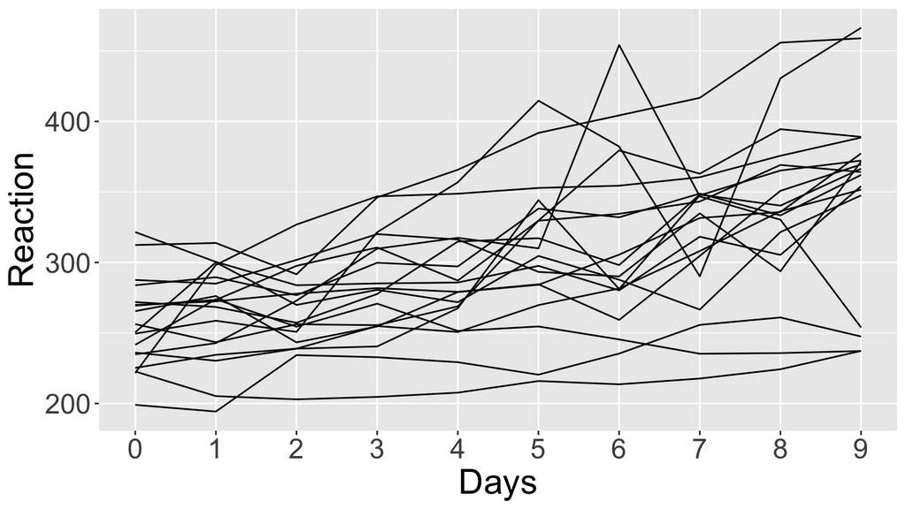

#### Conditional model using `lme4::lmer`, random intercept

```r
cm_sleep <- lmer(Reaction ~ Days + (1 | Subject), sleepstudy)
```

#### Marginal model using `lm` (OLS), assumes independent errors

```r
mm_sleep_ind <- lm(Reaction ~ Days, sleepstudy)
```

#### Marginal model using `nlme::gls`, compound symmetric error structure

```r
library(nlme)
mm_sleep_cs <- gls(Reaction ~ Days, sleepstudy,
                   correlation = corCompSymm(form = ~1|Subject))
```

#### Marginal model using `geepack::geeglm`, CS error structure + robust variance

```r
library(geepack)
mm_sleep_gee_cs <-
  geeglm(Reaction ~ Days,
         data = sleepstudy,
         id = Subject,
         corstr = "exchangeable")
```

#### Marginal model using `gee::gee`, same as above

```r
library(gee)
mm_sleep_gee_cs_alt <-
  gee(Reaction ~ Days, data = sleepstudy, id = Subject,
      corstr = "exchangeable")
```

```r
summary(cm_sleep)$coefficients
```

```
##             Estimate Std. Error t value
## (Intercept)   251.41     9.7467   25.79
## Days           10.47     0.8042   13.02
```

```r
summary(mm_sleep_ind)$coefficients
```

```
##             Estimate Std. Error t value  Pr(>|t|)
## (Intercept)   251.41      6.610  38.033 2.157e-87
## Days           10.47      1.238   8.454 9.894e-15
```

```r
summary(mm_sleep_cs)$tTable
```

```
##              Value Std.Error t-value   p-value
## (Intercept) 251.41    9.7467   25.79 5.024e-62
## Days         10.47    0.8042   13.02 1.210e-27
```

```r
summary(mm_sleep_gee_cs)$coefficients
```

```
##             Estimate Std.err    Wald  Pr(>|W|)
## (Intercept)   251.41   6.632 1436.89 0.000e+00
## Days           10.47   1.502   48.55 3.219e-12
```

```r
summary(mm_sleep_gee_cs_alt)$coefficients
```

```
##             Estimate Naive S.E. Naive z Robust S.E. Robust z
## (Intercept)   251.41      9.538   26.36       6.632   37.906
## Days           10.47      0.811   12.91       1.502    6.968
```

## An aside: `geeglm` and `gee` assume clusters are collected together

From `?gee`:

> Data are assumed to be sorted so that observations on a cluster are contiguous rows for all entities in the formula.

```r
set.seed(1)
sleepstudy %>%
  # Randomly permuting rows
  slice_sample(n = nrow(.)) %>%
  # gives different result
  geeglm(Reaction ~ Days,
         data = .,
         id = Subject,
         corstr = "exchangeable")
```

```
##
## Call:
## geeglm(formula = Reaction ~ Days, data = ., id = Subject, corstr = "exchangeable")
##
## Coefficients:
## (Intercept)        Days
##      248.68       11.06
##
## Degrees of Freedom: 180 Total (i.e. Null);  178 Residual
##
## Scale Link:                   identity
## Estimated Scale Parameters:  [1] 2254
##
## Correlation:  Structure = exchangeable    Link = identity
## Estimated Correlation Parameters:
##  alpha
## 0.6688
##
## Number of clusters:   164   Maximum cluster size: 2
```

Clusters are incorrectly identified with no warning. **Arrange your data by cluster**

## Was choice of constant correlation sensible?

```r
summary(mm_sleep_gee_cs)$corr
```

```
##       Estimate Std.err
## alpha    0.576  0.1114
```

## Residuals from marginal model

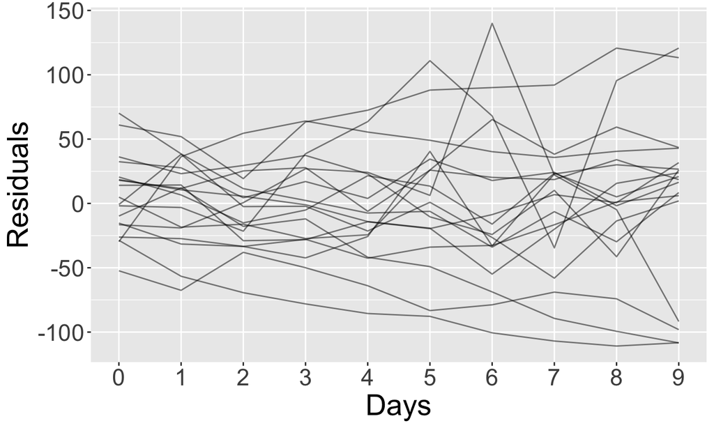

## Correlation plot from residuals

### Suggests non-constant correlation

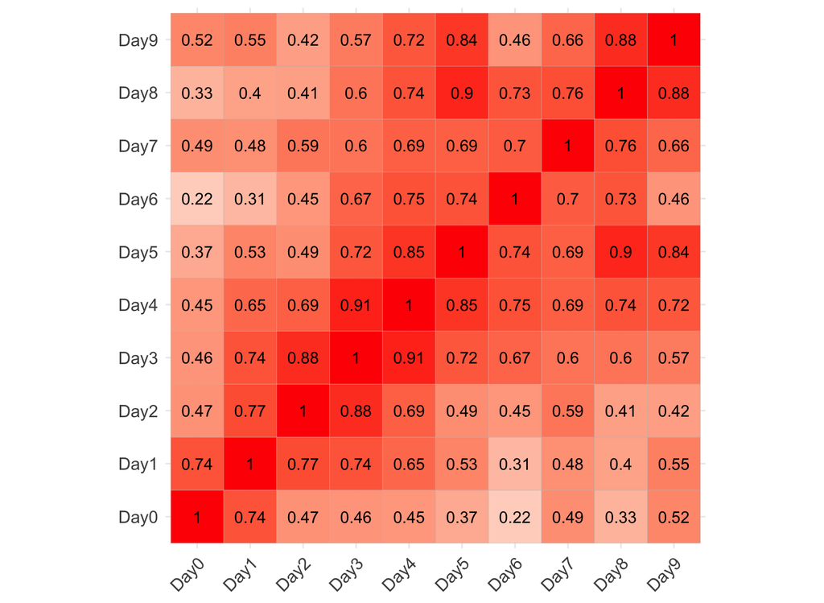

## Possible reaction 1: Change correlations structure in marginal model

```r
# Compound-symmetric correlation
summary(mm_sleep_gee_cs)$coefficients
```

```
##             Estimate Std.err    Wald  Pr(>|W|)
## (Intercept)   251.41   6.632 1436.89 0.000e+00
## Days           10.47   1.502   48.55 3.219e-12
```

```r
# Autoregressive-1 correlation
mm_sleep_gee_ar1 <-
  geeglm(Reaction ~ Days,
         data = sleepstudy,
         id = Subject,
         corstr = "ar1")
summary(mm_sleep_gee_ar1)$coefficients
```

```
##             Estimate Std.err    Wald  Pr(>|W|)
## (Intercept)   254.23   6.485 1536.69 0.000e+00
## Days           10.47   1.448   52.25 4.892e-13
```

## Possible reaction 2: Trust your robust standard error estimate

- Naive standard error under CS: 0.811
- Robust standard error under CS: 1.502
- Robust standard error under AR-1: 1.448

## Possible reaction 3: Add random slopes to conditional model

```r
summary(cm_sleep)$coefficients
```

```
##             Estimate Std. Error t value
## (Intercept)   251.41     9.7467   25.79
## Days           10.47     0.8042   13.02
```

```r
cm_sleep_random_slope <-
  lmer(Reaction ~ Days + (Days | Subject), sleepstudy);
summary(cm_sleep_random_slope)$coefficients
```

```
##             Estimate Std. Error t value
## (Intercept)   251.41      6.825  36.838
## Days           10.47      1.546   6.771
```

```r
extractAIC(cm_sleep)
```

```
## [1]    4 1802
```

```r
extractAIC(cm_sleep_random_slope) # Better fit with random slope
```

```
## [1]    6 1764
```

## Can get subject-specific predictions

#### Best Linear Unbiased Predictions (BLUPs), \(\hat{\mathbf{b}}_i\)

```
##     (Intercept)     Days
## 308      2.2586   9.1990
## 309    -40.3987  -8.6197
## 310    -38.9604  -5.4489
## 330     23.6906  -4.8144
## 331     22.2603  -3.0699
## 332      9.0396  -0.2722
## 333     16.8405  -0.2236
## 334     -7.2326   1.0746
## 335     -0.3337 -10.7522
## 337     34.8905   8.6283
## 349    -25.2102   1.1734
## 350    -13.0700   6.6142
## 351      4.5779  -3.0153
## 352     20.8637   3.5360
## 369      3.2755   0.8722
## 370    -25.6130   4.8225
## 371      0.8070  -0.9882
## 372     12.3146   1.2840
```

#### \((1/n) \sum_i \hat{\mathbf{b}}_i = 0\)

```
## (Intercept)        Days
##           0           0
```

## Can get subject-specific and population predictions

#### \(\mathbf{x}_i^\top \hat{\mathbf{\beta}} + \mathbf{z}_i^\top\hat{\mathbf{b}}_i\) (Subject ID) and \(\mathbf{x}_i^\top \hat{\mathbf{\beta}}\) (‘Population’) against Days

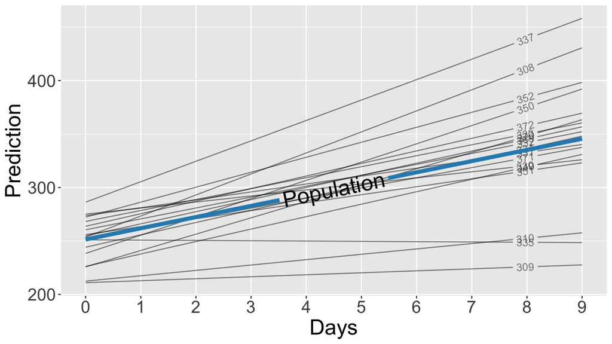

## Can get subject-specific predictions

#### \(\mathbf{x}_i^\top \hat{\mathbf{\beta}} + \mathbf{z}_i^\top\hat{\mathbf{b}}_i\) (solid) and \(\mathbf{Y}\) (dashed) against Days

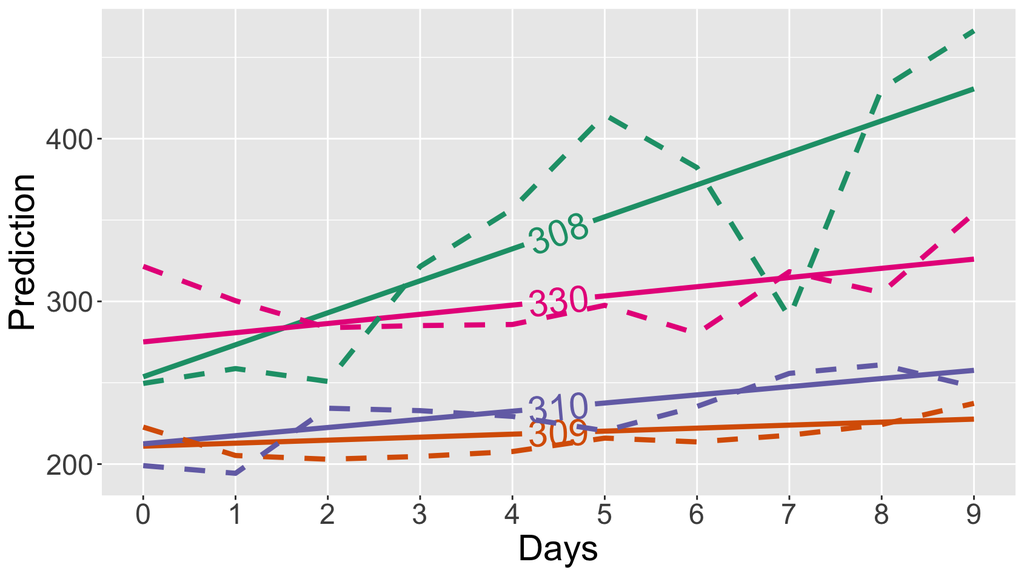

## Summary: Point estimates

Point estimates of \(\mathbf{\beta}\) are usually similar for conditional or marginal linear models, but standard errors may differ

Robust / sandwich variance estimator is doing its job

## Summary: Interpretation

### Conditional model with random intercept and slope:

\[ \begin{aligned} E[Y_i|x = a] &= \beta_0 + b_{0i} + a (\beta + b_{1i}) \\ E[Y_i|x = a + 1] &= \beta_0 + b_{0i} + (a + 1) (\beta + b_{1i})\\ E[Y_i|x = a + 1] - E[Y_i|x = a] &= \beta + b_{1i} \end{aligned} \] \(\beta + b_{1i}\) is change in expected outcome per 1-unit increase in \(x\) for an observation ingroup, and \(\beta\) is change in expected outcome per 1-unit increase in \(x\) when \(b_{1i}=0\), i.e. when \(b_{1i}\) is its population-average value

We are assuming group is held constant

## Summary: Interpretation

Interpretation of \(\mathbf{\beta}\) similar for conditional or marginal models. With one covariate:

### Marginal model

\[ \begin{aligned} E[Y_i|x = a] &= \beta_0 +a \beta\\ E[Y_i|x = a + 1] &= \beta_0 + (a + 1) \beta\\ E[Y_i|x = a + 1] - E[Y_i|x = a] &= \beta \end{aligned} \] \(\beta\) is change in expected outcome per 1-unit increase in \(x\)

We don’t have to assume that group is held constant

## More differences for non-linear link functions

For non-linear link functions:

- Point estimates are not same
- Interpretations may differ between conditional and marginal models, especially if you want to work on \(E[Y|x]\) scale (as opposed to \(g(E[Y|x])\) scale)

## References

Gregory Belenky, Nancy J. Wesensten, David R. Thorne, Maria L. Thomas, Helen C. Sing, Daniel P. Redmond, Michael B. Russo and Thomas J. Balkin (2003) Patterns of performance degradation and restoration during sleep restriction and subsequent recovery: a sleep dose-response study. Journal of Sleep Research 12, 1–12

Højsgaard, S., Halekoh, U. & Yan J. (2006) The R Package geepack for Generalized Estimating Equations Journal of Statistical Software, 15, 2, pp1–11

Vincent J Carey. Ported to R by Thomas Lumley, Brian Ripley. Files src/dgedi.f and src/dgefa.f are for LINPACK authored by Cleve Moler. Note that maintainers are not available to give advice on using a package they did not author. (2019). gee: Generalized Estimation Equation Solver. R package version 4.13-20. https://CRAN.R-project.org/package=gee

Pinheiro J, Bates D, DebRoy S, Sarkar D, R Core Team (2019). *nlme: Linear and Nonlinear Mixed Effects Models*. R package version 3.1-140, <URL: https://CRAN.R-project.org/package=nlme>.

Douglas Bates, Martin Maechler, Ben Bolker, Steve Walker (2015). Fitting Linear Mixed-Effects Models Using lme4. Journal of Statistical Software, 67(1), 1-48. doi:10.18637/jss.v067.i01.